# Data Visualization

# Margem de Lucro dos Produtos

```r
names(sku_cost_df
    )
```

```
[1] "cod_prod"    "data_inicio" "data_fim"    "custo"
```

```r
# Mesclando as tabelas de custo e preço baseadas em 'cod_prod'
product_profit_margin <- merge(sku_cost_df, sku_price_df, by ="cod_prod")# Calculando a margem de lucro
product_profit_margin$lucro <- product_profit_margin$preco - product_profit_margin$custo

# Mesclando com informações adicionais de produto, se necessário
product_profit_margin <- merge(product_profit_margin, sku_dataset_df, by ="cod_prod")
```

```r
head(product_profit_margin)
```

|  | cod_prod | data_inicio.x | data_fim.x | custo | data_inicio.y | data_fim.y | preco | lucro | nome_abrev | nome_completo | descricao | categoria | sub_categoria | marca | conteudo_valor | conteudo_medida |
| --- | --- | --- | --- | --- | --- | --- | --- | --- | --- | --- | --- | --- | --- | --- | --- | --- |
| 1 | 6587422396 | 2022-04-09 | 2022-12-30 | 33.17 | 2022-04-09 | 2022-06-20 | 41.99 | 8.82 | Prisme Libre Blush Flanelle | Prisme Libre Blush - Flanelle Rubis | Blush MAC Cosmetics Prisme Libre Blush - Flanelle Rubis para Rosto | Rosto | Blush | MAC Cosmetics | 30 | ml |
| 2 | 6587422396 | 2022-04-09 | 2022-12-30 | 33.17 | 2022-06-21 | 2022-09-01 | 41.99 | 8.82 | Prisme Libre Blush Flanelle | Prisme Libre Blush - Flanelle Rubis | Blush MAC Cosmetics Prisme Libre Blush - Flanelle Rubis para Rosto | Rosto | Blush | MAC Cosmetics | 30 | ml |
| 3 | 6587422396 | 2022-04-09 | 2022-12-30 | 33.17 | 2022-09-02 | 2022-11-13 | 41.99 | 8.82 | Prisme Libre Blush Flanelle | Prisme Libre Blush - Flanelle Rubis | Blush MAC Cosmetics Prisme Libre Blush - Flanelle Rubis para Rosto | Rosto | Blush | MAC Cosmetics | 30 | ml |
| 4 | 6587422396 | 2022-04-09 | 2022-12-30 | 33.17 | 2022-11-14 | 2023-01-25 | 42.99 | 9.82 | Prisme Libre Blush Flanelle | Prisme Libre Blush - Flanelle Rubis | Blush MAC Cosmetics Prisme Libre Blush - Flanelle Rubis para Rosto | Rosto | Blush | MAC Cosmetics | 30 | ml |
| 5 | 6587422396 | 2022-04-09 | 2022-12-30 | 33.17 | 2023-01-26 | 2023-04-08 | 44.99 | 11.82 | Prisme Libre Blush Flanelle | Prisme Libre Blush - Flanelle Rubis | Blush MAC Cosmetics Prisme Libre Blush - Flanelle Rubis para Rosto | Rosto | Blush | MAC Cosmetics | 30 | ml |
| 6 | 6587422396 | 2022-04-09 | 2022-12-30 | 33.17 | 2023-04-09 | 2023-06-20 | 44.99 | 11.82 | Prisme Libre Blush Flanelle | Prisme Libre Blush - Flanelle Rubis | Blush MAC Cosmetics Prisme Libre Blush - Flanelle Rubis para Rosto | Rosto | Blush | MAC Cosmetics | 30 | ml |

### Verificando a estrutura do data frame ‘product_profit_margin’

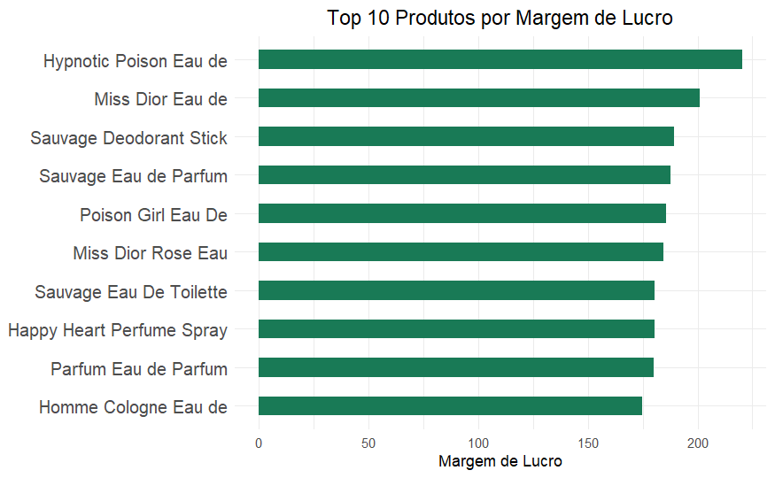

```r
library(dplyr)# Supondo que 'product_profit_margin' é o seu data frame já com a margem de lucro calculada# Removendo duplicatas baseado em 'nome_abrev' e mantendo o de maior lucro
unique_products <- product_profit_margin %>%
  arrange(desc(lucro))%>%
  distinct(nome_abrev, .keep_all =TRUE)# Selecionando os top 10 produtos únicos
top_products <- unique_products %>%
  head(10)# Criando o gráfico
library(ggplot2)
ggplot(top_products, aes(x=reorder(nome_abrev, lucro), y=lucro))+
  geom_bar(stat="identity", fill="#197a56", width=0.5)+# Especificando a largura das barras
  coord_flip()+# Fazendo o gráfico horizontal
  labs(title="Top 10 Produtos por Margem de Lucro", x="", y="Margem de Lucro")+
  theme_minimal()+
  theme(axis.text.y = element_text(angle=0, hjust=1, size=12),
        axis.title.y = element_blank(),
        plot.title = element_text(hjust=0.5, size=14))# Salvar o gráfico
```

```r
#ggsave("top10_products_profit.png", plot = last_plot(), width =12, height =8, dpi =300)
```

Este gráfico mostra os dez produtos com as maiores margens de lucro, destacando itens como “Hypnotic Poison Eau de Parfum” e “Miss Dior Eau de Parfum” como os mais lucrativos. Outros produtos de destaque incluem “Sauvage Deodorant Stick” e “Poison Girl Eau de Parfum”, que também apresentam margens de lucro elevadas.

```r
library(dplyr)# Calculando a margem total de lucro por marca
marca_lucro <- product_profit_margin %>%
  group_by(marca)%>%
  summarise(total_lucro =sum(lucro), .groups ='drop')%>%
  arrange(desc(total_lucro))# Se você quiser ver a margem média de lucro em vez do total
marca_lucro_media <- product_profit_margin %>%
  group_by(marca)%>%
  summarise(media_lucro = mean(lucro), .groups ='drop')%>%
  arrange(desc(media_lucro))
```

```r
# Top 10 marcas por margem total de lucro
top_marcas <- head(marca_lucro,10)# Top 10 marcas por margem média de lucro
top_marcas_media <- head(marca_lucro_media,10)
```

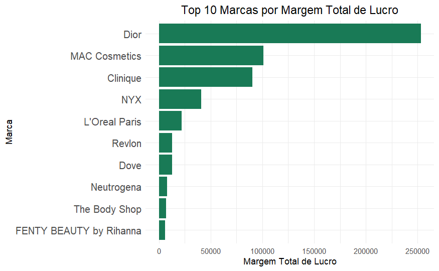

```r
library(ggplot2)# Gráfico para margem total de lucro
ggplot(top_marcas, aes(x=reorder(marca, total_lucro), y=total_lucro, fill=marca))+
  geom_col(fill="#197a56")+# Cor verde específica
  coord_flip()+
  labs(title="Top 10 Marcas por Margem Total de Lucro", x="Marca", y="Margem Total de Lucro")+
  theme_minimal()+
  theme(axis.text.y = element_text(size=12),
        plot.title = element_text(hjust=0.5, size=14),
        legend.position ="none")# Remove a legenda, já que a cor é uniforme# Gráfico para margem média de lucro
```

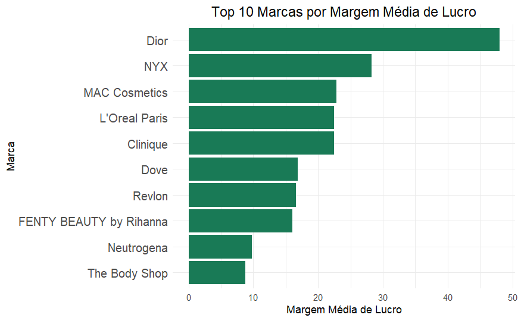

```r
ggplot(top_marcas_media, aes(x=reorder(marca, media_lucro), y=media_lucro, fill=marca))+
  geom_col(fill="#197a56")+# Cor verde específica
  coord_flip()+
  labs(title="Top 10 Marcas por Margem Média de Lucro", x="Marca", y="Margem Média de Lucro")+
  theme_minimal()+
  theme(axis.text.y = element_text(size=12),
        plot.title = element_text(hjust=0.5, size=14),
        legend.position ="none")# Remove a legenda, já que a cor é uniforme# Salvar ou exibir os gráficos
```

```r
#ggsave("top_marcas_total_lucro_verde.png", plot = last_plot(), width =12, height =8, dpi =300)
#ggsave("top_marcas_media_lucro_verde.png", plot = last_plot(), width =12, height =8, dpi =300)
```

Neste gráfico, as marcas são ordenadas pela margem média de lucro, com Dior destacando-se significativamente à frente das demais. NYX e MAC Cosmetics também aparecem com margens consideráveis, seguidas por L’Oréal Paris, Clinique, e Dove.